# Svect: An tool for Fast Vectorial Alignments

Roberto Raitz, Mariane Gonçalves Kulik, Ricardo Voyceik, Letícia Graziela Costa Santos de Mattos, Josué Oliveira Camargo, Aryel Marlus Repula de Oliveira, Bruno Thiago de Lima Nichio, Jeroniza Nunes Marchaukoski, Antonio Camilo da Silva Filho, Dieval Guizelini, José Miguel Ortega, Fabio de Oliveira Pedrosa and Danrley Rafael Fernandes

Federal University of Paraná, Graduate Program in Bioinformatics, Curitiba, Paraná, Brazil.  
Federal University of Paraná, Department of Biochemistry and Molecular Biology, Curitiba, Paraná, Brazil.  
Federal University of Paraná, Department of Genetics, Curitiba, Paraná, Brazil.  
Federal University of Minas Gerais, Institute of Biological Sciences (ICB), Belo Horizonte, Minas Gerais, Brazil.  
Federal University of Paraná, Department of Pharmaceutical Sciences, Curitiba, Paraná, Brazil.  
Federal University of Paraná, Graduate in Biological Sciences, Curitiba, Paraná, Brazil.

25 junho 2019

#### Abstract

This is a package with a couple of functions to possibilite the use of the SWeep method in R. It is a tool that vises to provide for fast alignment free DNA analysis.

#### Package

SVect 0.99.0

# 1 Overview

The “Spaced Words Projection (SWeeP)” is a method for representing biological sequences using relatively, it uses the spacedwords concept by scanning sequences and generating indices to create a higherdimensional vector that is later projected into a smaller randomly oriented orthonormal base. This function is suitable for making high quality comparisons between sequences allowing analyzes that are not possible due to the computational limitation of the traditional techniques. The method is available at [SWeeP](https://sourceforge.net/projects/spacedwordsprojection/) (PIERRI, 2019). This tool has it’s main speed gain in constanci processing time. The response time grows linear to the number of inputs, while in other methods it grow is exponencial.

## 1.1 Functions

The package has two functions: orthbase, that generates an orthonormal matrix of a chosen size, and SWeeP, a function that applies the SWeeP method

# 2 Quick Start

The orthbase function can create a orthonormal matrix in any desired size. Here it is used to create a matrix to project the SWeeP method, so it must have 160.000 rows and the columns of the size wished for projection.

```r
library(SVect)
baseMatrix <- orthbase(160000,10)
```

```r
data(datastring)
cat(datastring, file = "exdna.fas", sep = "\n")
```

Then the SWeeP method is applied and the returns a matrix that represents the sequences compared by a vectorial method. And then it’s possible to see a graphic representation in a phylogenetic tree

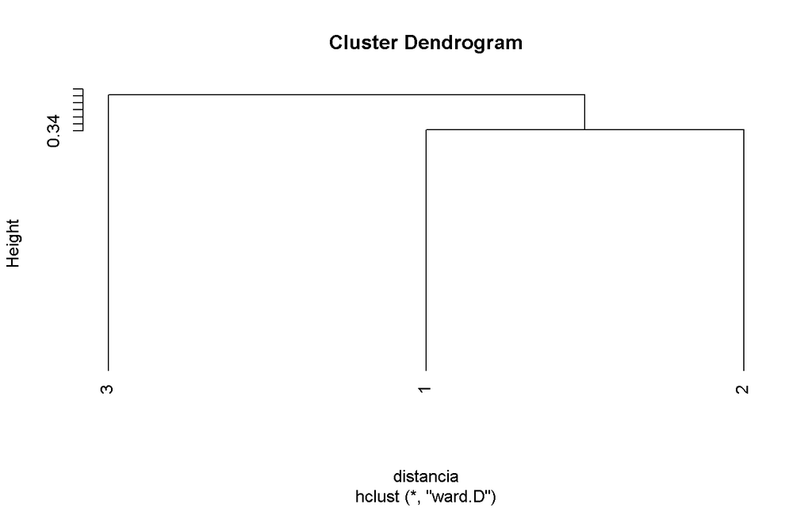

```r
return <- SWeeP("exdna.fas",baseMatrix)
distancia <- dist(return, method = "euclidean")
tree <- hclust(distancia, method="ward.D")
plot(tree, hang = -1, cex = 1)
```

# 4 References

- Pierri,C. R. *et al*. **SWeeP: Representing large biological sequences data sets in compact vectors**. (2019).